# FE8828 Assignment for Exploratory Data Analysis

Toh Zhao Zhi <sub><Email: tohz0016pg@e.ntu.edu.sg></sub>

Nov 19, 2017

# Finding #1

This data contains 4521 number of data points.

# Finding #2 Marital Status Demographics of Sample

Proportion of data sample for each marital status:

```r
# Find Percentage of people with different marital status
MARITAL.summary<- group_by(bank, marital) %>% summarise(n = n())

MARITAL.summary
```

```
## # A tibble: 3 x 2
##    marital     n
##     <fctr> <int>
## 1 divorced   528
## 2  married  2797
## 3   single  1196
```

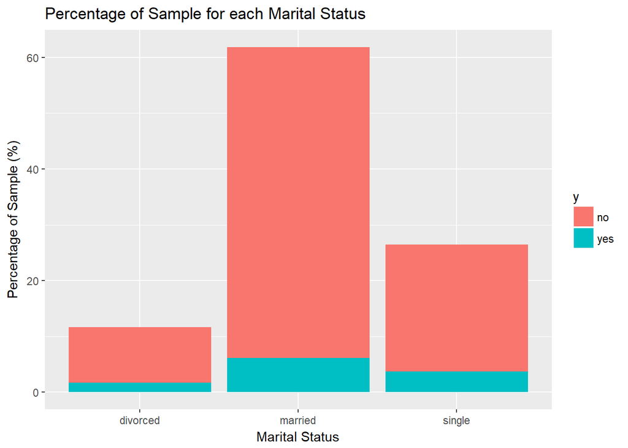

```r
# Marital Status and dependent variable
MARITAL.summary2<- group_by(bank, marital, y) %>% summarise(percentage = n()/nrow(bank)*100)

ggplot() + labs(x = "Marital Status", y = "Percentage of Sample (%)") + geom_bar(aes(y = percentage, x = marital, fill = y), data = MARITAL.summary2, stat = "identity") + ggtitle("Percentage of Sample for each Marital Status")
```

528 of the people in the sample are divorced, 2797 are married and 1196 are single of which majority of the people in each category have not subscribed to the term deposit.

# Finding #3 Age Demographics of Sample

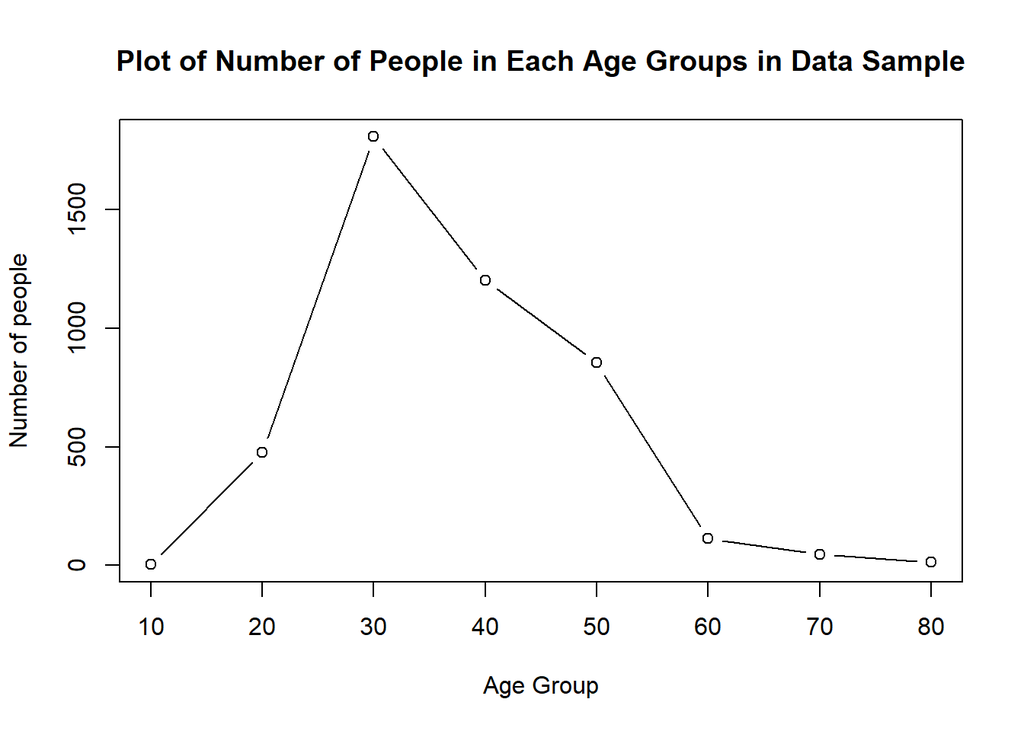

```r
bank %>%
  group_by(age_group = (age %/% 10) * 10) %>%
  summarise(count = n(), balance_mean = mean(balance)) %>%
  arrange(age_group) -> AGE.Summary

plot(AGE.Summary$age_group, AGE.Summary$count, type = "b", ylab = "Number of people",  xlab = "Age Group", main = "Plot of Number of People in Each Age Groups in Data Sample")
```

# Finding #4 Mean Balance across Age Groups

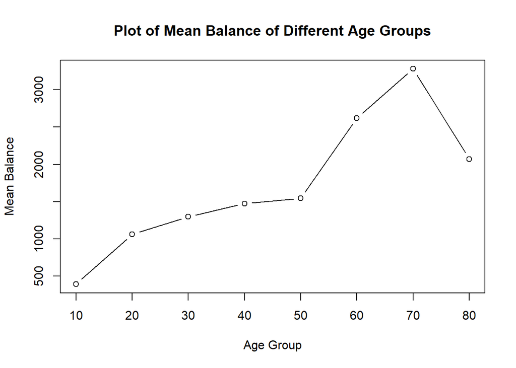

```r
plot(AGE.Summary$age_group, AGE.Summary$balance_mean, type = "b", ylab = "Mean Balance", xlab = "Age Group", main = "Plot of Mean Balance of Different Age Groups")
```

```r
AGE.Summary
```

```
## # A tibble: 8 x 3
##   age_group count balance_mean
##       <dbl> <int>        <dbl>
## 1        10     4      393.500
## 2        20   478     1063.657
## 3        30  1808     1298.147
## 4        40  1203     1474.692
## 5        50   854     1547.420
## 6        60   113     2619.779
## 7        70    47     3280.872
## 8        80    14     2071.143
```

The above plot shows the mean balance across different age groups and it can be observed that on average, people above 60 years old have higher balances as compared to people below 60 years old. People in their 70s have highest mean balance, while people aged 10+ have the lowest mean balance.

# Finding #5 Likelihood of default in each job category

```r
bank %>%
  group_by(job) %>%
  summarise(default_count = sum(ifelse(default == "no", 0,1)), total = sum(ifelse(loan == "yes" | housing == "yes", 0,1)), likelihood.default = default_count/total*100) -> JOB.Summary
JOB.Summary
```

```
## # A tibble: 12 x 4
##              job default_count total likelihood.default
##           <fctr>         <dbl> <dbl>              <dbl>
##  1        admin.             6   141           4.255319
##  2   blue-collar            14   198           7.070707
##  3  entrepreneur             7    62          11.290323
##  4     housemaid             2    65           3.076923
##  5    management            14   407           3.439803
##  6       retired             3   161           1.863354
##  7 self-employed             4    80           5.000000
##  8      services             7    99           7.070707
##  9       student             1    63           1.587302
## 10    technician            15   298           5.033557
## 11    unemployed             3    66           4.545455
## 12       unknown             0    37           0.000000
```

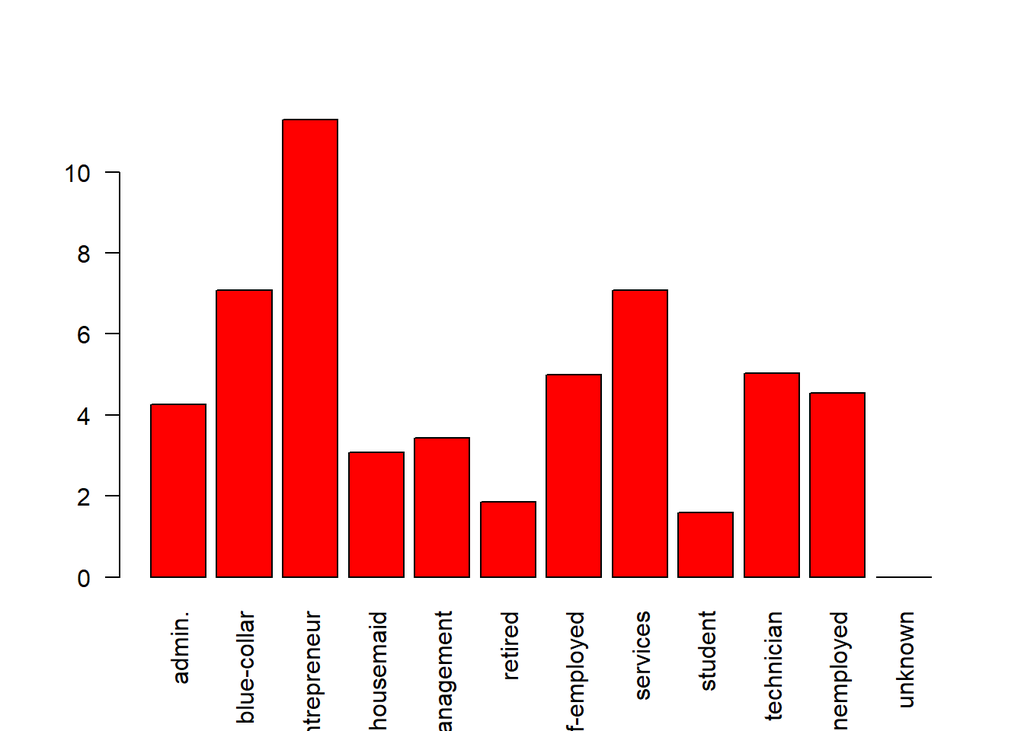

```r
barplot(JOB.Summary$likelihood.default, names.arg = JOB.Summary$job, las = 2, col = "red")
```

The above bar chart shows the default likelihood across different job categories. It can be seen that entrepreneurs have the highest possibility of defaulting on their loans, while unknown, students and retired have the lowest possibility of defaulting on their loans.

# Finding #6 Education-Job Relationship

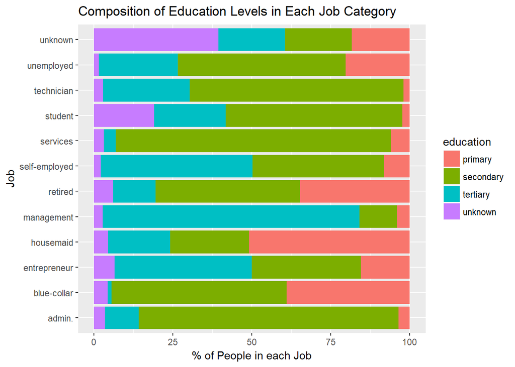

```r
bank %>%
  group_by(job, education) %>%
  summarise(n = n()) %>% mutate(percent = n/sum(n)*100) -> JOBxEDU.Summary

ggplot() + labs(x = "Job", y = "% of People in each Job") + geom_bar(aes(y = percent, x = job, fill = education), data = JOBxEDU.Summary, stat = "identity") + coord_flip() +  ggtitle("Composition of Education Levels in Each Job Category")
```

```r
names(JOBxEDU.Summary)[4] = "Percentage in Job Category"
JOBxEDU.Summary
```

```
## # A tibble: 48 x 4
## # Groups:   job [12]
##             job education     n `Percentage in Job Category`
##          <fctr>    <fctr> <int>                        <dbl>
##  1       admin.   primary    17                     3.556485
##  2       admin. secondary   393                    82.217573
##  3       admin.  tertiary    51                    10.669456
##  4       admin.   unknown    17                     3.556485
##  5  blue-collar   primary   369                    39.006342
##  6  blue-collar secondary   524                    55.391121
##  7  blue-collar  tertiary    12                     1.268499
##  8  blue-collar   unknown    41                     4.334038
##  9 entrepreneur   primary    26                    15.476190
## 10 entrepreneur secondary    58                    34.523810
## # ... with 38 more rows
```

The above chart shows the composition of Education Levels in Each Job Category. It can be seen that management level jobs are mostly taken up by people with tertiary education level, while services, admin, services, technicians are mostly taken up by people with secondary education. Housemaids is mainly composed of people with primary education.

# Finding #7 Job-Age Relationship

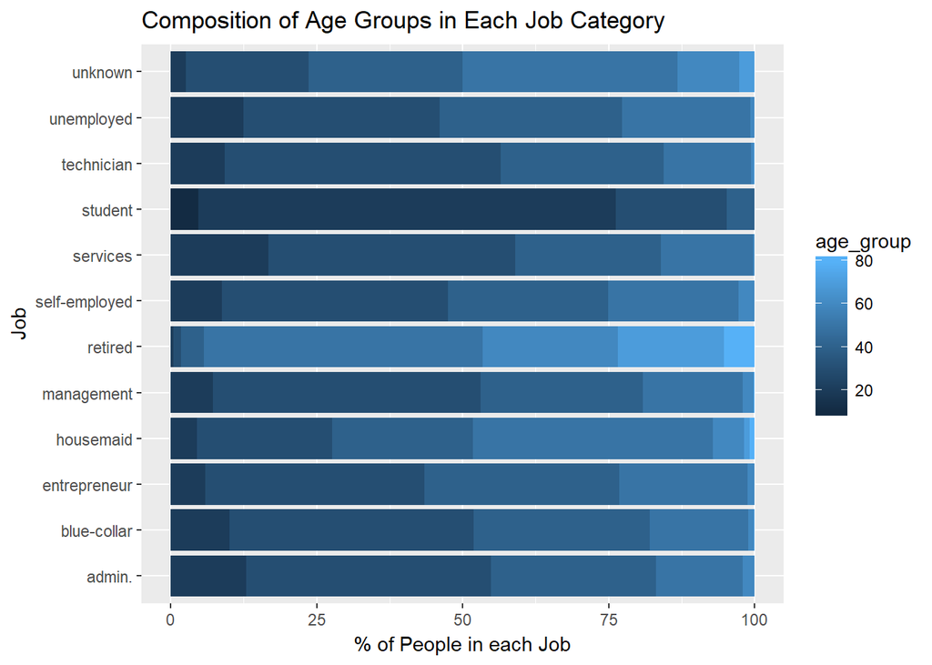

```r
bank %>% mutate(age_group = (age %/% 10) * 10) -> temp

temp %>%  group_by(job, age_group) %>%
  summarise(n = n()) %>% mutate(percent = n/sum(n)*100) -> JOBxAGE.Summary

ggplot() + labs(x = "Job", y = "% of People in each Job") + geom_bar(aes(y = percent, x = job, fill = age_group), data = JOBxAGE.Summary, stat = "identity") + coord_flip() +  ggtitle("Composition of Age Groups in Each Job Category")
```

```r
names(JOBxAGE.Summary)[4] = "Percentage in Job Category"
JOBxAGE.Summary
```

```
## # A tibble: 67 x 4
## # Groups:   job [12]
##            job age_group     n `Percentage in Job Category`
##         <fctr>     <dbl> <int>                        <dbl>
##  1      admin.        20    62                    12.970711
##  2      admin.        30   200                    41.841004
##  3      admin.        40   135                    28.242678
##  4      admin.        50    71                    14.853556
##  5      admin.        60    10                     2.092050
##  6 blue-collar        20    96                    10.147992
##  7 blue-collar        30   395                    41.754757
##  8 blue-collar        40   285                    30.126850
##  9 blue-collar        50   160                    16.913319
## 10 blue-collar        60     8                     0.845666
## # ... with 57 more rows
```

# Finding #8 Min and Max Balance in each job category

```r
bank %>%
  group_by(job) %>%
  summarize(min_balance = min(balance), max_balance = max(balance), mean_balance = mean(balance)) -> JOBxBALANCE.Summary

JOBxBALANCE.Summary
```

```
## # A tibble: 12 x 4
##              job min_balance max_balance mean_balance
##           <fctr>       <dbl>       <dbl>        <dbl>
##  1        admin.        -967       22171     1226.736
##  2   blue-collar       -1400       16353     1085.162
##  3  entrepreneur       -2082       42045     1645.125
##  4     housemaid        -759       26965     2083.804
##  5    management       -1746       27359     1766.929
##  6       retired       -1206       71188     2319.191
##  7 self-employed       -3313       16430     1392.410
##  8      services       -1202       26394     1103.957
##  9       student        -230       11555     1543.821
## 10    technician       -1680       27733     1330.996
## 11    unemployed        -872        9019     1089.422
## 12       unknown           0        7337     1501.711
```

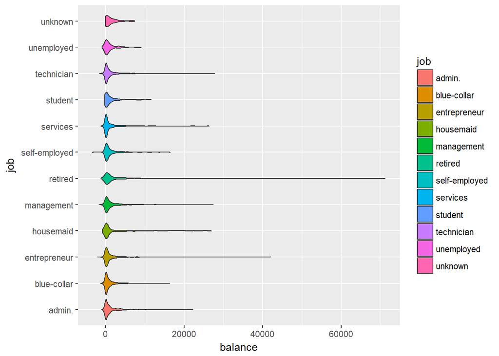

```r
ggplot(data=bank, aes(x=job, y=balance, fill=job)) +
geom_violin() + coord_flip()
```

The above plot shows the distribution of balance in the different job categories. The maximum balance of the sample comes from the retired category (71188), while the minimum balance of the sample comes from the self-employed category (-3313).

# Finding #9 Age range of people with housing loan

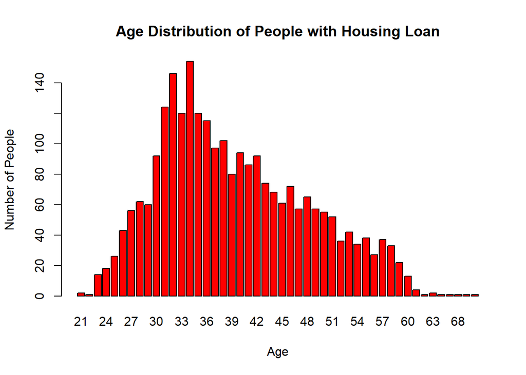

```r
bank %>%
  group_by(age, housing) %>%
  summarize(n = n()) %>%
  filter(housing == "yes") -> AGExHOUSING.Summary

barplot(AGExHOUSING.Summary$n, names.arg = AGExHOUSING.Summary$age, main = "Age Distribution of People with Housing Loan", xlab = "Age", ylab = "Number of People", col = "red")
```

```r
AGExHOUSING.Summary
```

```
## # A tibble: 48 x 3
## # Groups:   age [48]
##      age housing     n
##    <int>  <fctr> <int>
##  1    21     yes     2
##  2    22     yes     1
##  3    23     yes    14
##  4    24     yes    18
##  5    25     yes    26
##  6    26     yes    43
##  7    27     yes    56
##  8    28     yes    62
##  9    29     yes    60
## 10    30     yes    92
## # ... with 38 more rows
```

The above chart shows the age distribution of people with housing loan. The age range of people with housing loan is 21 to 75. It can be seen that the bulk of people with housing loans are aged 30-42, with the age 34 having the most people with a housing loan. In general, as age increases/decreases from the 30s, the number of people having housing loans decreases.

# Finding #10 Age range of people with personal loan

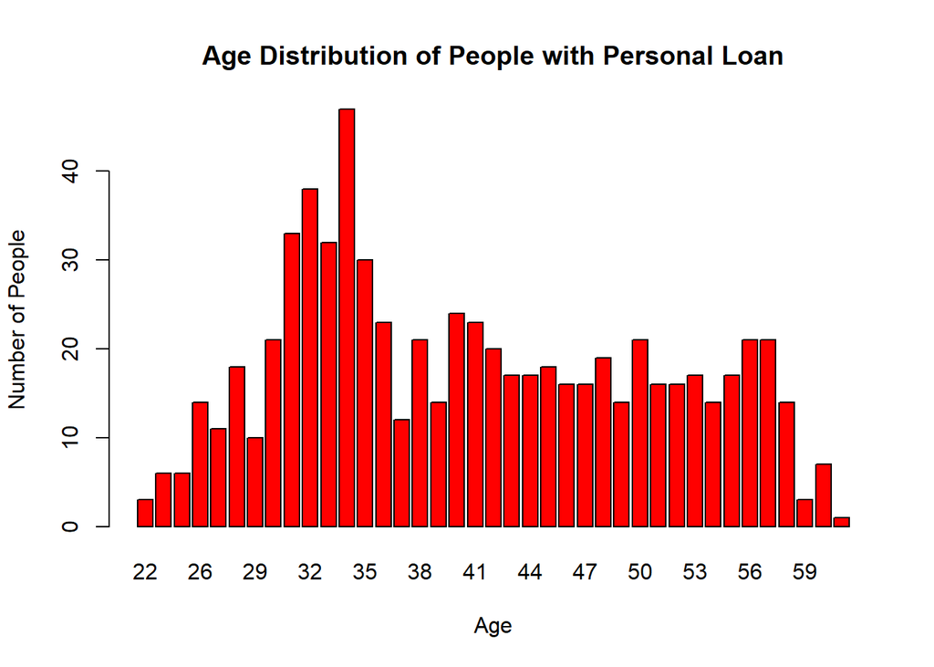

```r
bank %>%
  group_by(age, loan) %>%
  summarize(n = n()) %>%
  filter(loan == "yes") -> AGExLOAN.Summary

barplot(AGExLOAN.Summary$n, names.arg = AGExLOAN.Summary$age, main = "Age Distribution of People with Personal Loan", xlab = "Age", ylab = "Number of People", col = "red")
```

```r
AGExLOAN.Summary
```

```
## # A tibble: 39 x 3
## # Groups:   age [39]
##      age   loan     n
##    <int> <fctr> <int>
##  1    22    yes     3
##  2    24    yes     6
##  3    25    yes     6
##  4    26    yes    14
##  5    27    yes    11
##  6    28    yes    18
##  7    29    yes    10
##  8    30    yes    21
##  9    31    yes    33
## 10    32    yes    38
## # ... with 29 more rows
```